# Analyzing Kyphosis Dataset

Author

Sathwik Bollepalli

Published

November 11, 2023

```r
library(rpart)
data(kyphosis)
head(kyphosis)
```

```
  Kyphosis Age Number Start
1   absent  71      3     5
2   absent 158      3    14
3  present 128      4     5
4   absent   2      5     1
5   absent   1      4    15
6   absent   1      2    16
```

**A)**

Splittig the data into train and test in the ration 90:10.

```r
set.seed(123457)
train.prop <- 0.90

strats <- kyphosis$Kyphosis
rr <- split(1:length(strats), strats)
idx <- sort(as.numeric(unlist(sapply(rr,
        function(x) sample(x, length(x)*train.prop)))))
kyphosis.train <- kyphosis[idx, ]
kyphosis.test <- kyphosis[-idx, ]
```

```r
dim(kyphosis.train)
```

```
[1] 72  4
```

```r
dim(kyphosis.test)
```

```
[1] 9 4
```

```r
table(kyphosis$Kyphosis)
```

```
 absent present
     64      17
```

```r
summary(kyphosis$Kyphosis)/nrow(kyphosis)
```

```
   absent   present
0.7901235 0.2098765
```

```r
table(kyphosis.train$Kyphosis)
```

```
 absent present
     57      15
```

```r
summary(kyphosis.train$Kyphosis)/nrow(kyphosis.train)
```

```
   absent   present
0.7916667 0.2083333
```

```r
table(kyphosis.test$Kyphosis)
```

```
 absent present
      7       2
```

```r
summary(kyphosis.test$Kyphosis)/nrow(kyphosis.test)
```

```
   absent   present
0.7777778 0.2222222
```

As we can see from the output the proportion of the outcome binary response variable are approximately same in entire, train and test data set.

If the proportions of the binary response are not equal in the train, test and entire data, the model might be trained on a non-representative dataset, which could bias its predictions. For example, if the training data has fewer instances of Kyphosis=present than the full dataset, the model might not learn to predict this class as effectively, leading to poor performance.

**B)**

```r
model.full.logit <- glm(Kyphosis ~ . ,data = kyphosis.train,
                  family = binomial(link = "logit"))
summary(model.full.logit)
```

```
Call:
glm(formula = Kyphosis ~ ., family = binomial(link = "logit"),
    data = kyphosis.train)

Coefficients:
             Estimate Std. Error z value Pr(>|z|)
(Intercept) -1.047104   1.584372  -0.661  0.50868
Age          0.009606   0.007057   1.361  0.17343
Number       0.317924   0.237262   1.340  0.18026
Start       -0.260587   0.079381  -3.283  0.00103 **
---
Signif. codes:  0 '***' 0.001 '**' 0.01 '*' 0.05 '.' 0.1 ' ' 1

(Dispersion parameter for binomial family taken to be 1)

    Null deviance: 73.691  on 71  degrees of freedom
Residual deviance: 50.402  on 68  degrees of freedom
AIC: 58.402

Number of Fisher Scoring iterations: 5
```

The intercept coefficient is -1.047104 with a standard error of 1.584372. This value represents the log odds of the outcome when all the predictor variables are held at zero.

The coefficient for Age is 0.009606 this suggests that with each additional month of age, the log odds of having Kyphosis increase by approximately 0.009606.

The coefficient for Number is 0.317924 which implies that with each additional vertebral segment involved, the log odds of having Kyphosis increase by about 0.317924.

The coefficient for Start is -0.260587 this means that with each additional level down the spine at which the surgery starts, the log odds of having Kyphosis decrease by about 0.260587. The p-value of 0.00103 indicates that this predictor is statistically significant at the 0.05 level.

```r
model.null.logit <- glm(Kyphosis ~ 1 ,data = kyphosis.train,
                  family = binomial(link = "logit"))
summary(model.null.logit)
```

```
Call:
glm(formula = Kyphosis ~ 1, family = binomial(link = "logit"),
    data = kyphosis.train)

Coefficients:
            Estimate Std. Error z value Pr(>|z|)
(Intercept)  -1.3350     0.2902    -4.6 4.22e-06 ***
---
Signif. codes:  0 '***' 0.001 '**' 0.01 '*' 0.05 '.' 0.1 ' ' 1

(Dispersion parameter for binomial family taken to be 1)

    Null deviance: 73.691  on 71  degrees of freedom
Residual deviance: 73.691  on 71  degrees of freedom
AIC: 75.691

Number of Fisher Scoring iterations: 4
```

This model uses only an intercept and no predictor variables to classify the dependent variable.

The estimate for the intercept is -1.3350 represents the log odds of having Kyphosis when no predictors are included in the model.

$$H_0:\text{Data prefers Full model}\\
H_a:\text{Data does not prefer the Full model}$$

```r
with(model.full.logit, cbind(deviance = deviance, df = df.residual,
     p = pchisq(deviance, df.residual, lower.tail=FALSE)))
```

```
     deviance df         p
[1,] 50.40162 68 0.9457257
```

Also, as we can see from the chi-square test the high p-value of 0.9 indicates to fail to reject H0, therefore meaning that the data prefers the full model more than the null model.

**C)**

**ROC-Train data**

```r
library(pROC)
pred.full <- predict(model.full.logit, newdata = kyphosis.train, type="response")
pred.null <- predict(model.null.logit, newdata = kyphosis.train, type="response")

roc.full <- roc(kyphosis.train$Kyphosis, pred.full, levels=c('absent','present'))
roc.full
```

```
Call:
roc.default(response = kyphosis.train$Kyphosis, predictor = pred.full,     levels = c("absent", "present"))

Data: pred.full in 57 controls (kyphosis.train$Kyphosis absent) < 15 cases (kyphosis.train$Kyphosis present).
Area under the curve: 0.8819
```

```r
roc.null <- roc(kyphosis.train$Kyphosis, pred.null, levels=c('absent','present'))
roc.null
```

```
Call:
roc.default(response = kyphosis.train$Kyphosis, predictor = pred.null,     levels = c("absent", "present"))

Data: pred.null in 57 controls (kyphosis.train$Kyphosis absent) < 15 cases (kyphosis.train$Kyphosis present).
Area under the curve: 0.5
```

The full model has an AUC of 0.8819 on the train data, suggesting that the model has a very good ability to discriminate between patients with Kyphosis and those without it based on the predictors included in the full model.

The null model has an AUC of 0.5, which is equivalent to random guessing.

**ROC-Test Data**

```r
pred.full <- predict(model.full.logit, newdata = kyphosis.test, type="response")
pred.null <- predict(model.null.logit, newdata = kyphosis.test, type="response")

roc.full <- roc(kyphosis.test$Kyphosis, pred.full, levels=c('absent','present'))
roc.full
```

```
Call:
roc.default(response = kyphosis.test$Kyphosis, predictor = pred.full,     levels = c("absent", "present"))

Data: pred.full in 7 controls (kyphosis.test$Kyphosis absent) < 2 cases (kyphosis.test$Kyphosis present).
Area under the curve: 0.5714
```

```r
roc.null <- roc(kyphosis.test$Kyphosis, pred.null, levels=c('absent','present'))
roc.null
```

```
Call:
roc.default(response = kyphosis.test$Kyphosis, predictor = pred.null,     levels = c("absent", "present"))

Data: pred.null in 7 controls (kyphosis.test$Kyphosis absent) < 2 cases (kyphosis.test$Kyphosis present).
Area under the curve: 0.5
```

The full model has an AUC of 0.5714 on the test data. An AUC of 0.5714 means the model can correctly distinguish between a patient with Kyphosis and one without it 57.14% of the time.

The null model has an AUC of 0.5 on the test data.

**D)**

```r
age_coef <- coef(model.full.logit)["Age"]
age_coef
```

```
        Age
0.009606047
```

**Logit Interpretation:**

For each one-unit increase in Age, the log odds of having Kyphosis present, increase by, 0.0096 considering that other factors are held constant.

This is a relatively small increase, which suggests that Age, by itself, might not be a strong predictor of the presence of Kyphosis post-surgery.

**Probability Interpretation**:

$$P(\text{Kyphosis} = \text{present} \,|\, \text{Age}) = \frac{e^{\beta_0 + \beta_1 \times \text{Age}}}{1 + e^{\beta_0 + \beta_1 \times \text{Age}}}$$

For example for a child aged 60 months we calculate the probability of Kyphosis being present :

$$P(\text{Kyphosis} = \text{present} \,|\, \text{Age} = 60) = \frac{e^{-1.047104 + 0.009606 \times 60}}{1 + e^{-1.047104 + 0.009606 \times 60}}$$

$$\begin{align*}P(\text{Kyphosis} = \text{present} \,|\, \text{Age} = 60) &= \frac{e^{-1.047104 + 0.009606 \times 60}}{1 + e^{-1.047104 + 0.009606 \times 60}} \\&= \frac{e^{-1.047104 + 0.57636}}{1 + e^{-1.047104 + 0.57636}} \\&= \frac{e^{-0.470744}}{1 + e^{-0.470744}} \\&= \frac{1}{1 + e^{0.470744}} \\&\approx \frac{1}{1 + 1.601} \\&\approx \frac{1}{2.601} \\&\approx 0.384\end{align*}$$

For a child aged 60 months, the mode predicts the probability of Kyphosis presence if 0.384, given that other factors are held constant.

**E)**

$$H_0: \beta_{\text{Age}} = 0 \\
H_a: \beta_{\text{Age}} \neq 0$$

In Words:

$$H_0: \text{ Age Has no Effect} \\
H_a: \text{ Age Has an Effect}$$

```r
# Coefficient and standard error for Age from the model output
beta_age <- 0.009606
se_age <- 0.007057

# Calculate the Wald test statistic
wald_test_statistic <- beta_age / se_age

# Calculate the p-value for the test statistic
# Note: This should be a two-tailed test since we're testing for inequality in the hypothesis
p_value <- 2 * (1 - pnorm(abs(wald_test_statistic)))

# Output the Wald test statistic and p-value
list(wald_test_statistic = wald_test_statistic, p_value = p_value)
```

```
$wald_test_statistic
[1] 1.361202

$p_value
[1] 0.17345
```

The z-value is given in the output as 1.361, and the p-value for this test is 0.17345.

Given that the p-value is greater than 0.05, we would not reject the null hypothesis at the 5% significance level, meaning we do not have sufficient evidence to say that Age has a statistically significant effect on the probability of kyphosis presence.

**F)**

```r
model.reduced.logit <- glm(Kyphosis ~ Age, data=kyphosis.train, family = binomial(link = "logit"))
summary(model.reduced.logit)
```

```
Call:
glm(formula = Kyphosis ~ Age, family = binomial(link = "logit"),
    data = kyphosis.train)

Coefficients:
             Estimate Std. Error z value Pr(>|z|)
(Intercept) -1.744365   0.555998  -3.137   0.0017 **
Age          0.004610   0.005076   0.908   0.3637
---
Signif. codes:  0 '***' 0.001 '**' 0.01 '*' 0.05 '.' 0.1 ' ' 1

(Dispersion parameter for binomial family taken to be 1)

    Null deviance: 73.691  on 71  degrees of freedom
Residual deviance: 72.854  on 70  degrees of freedom
AIC: 76.854

Number of Fisher Scoring iterations: 4
```

The age intercept which in non significant says that for each unit increase in age the log odds of kyphosis increases by 0.0046.

If we go by AIC values, we prefer the full model.

```r
full_model_predictions <- predict(model.full.logit, newdata = kyphosis.test, type = "response")
reduced_model_predictions <- predict(model.reduced.logit, newdata = kyphosis.test, type = "response")

# Convert predictions to binary outcomes based on a 0.5 cutoff
full_model_pred_class <- ifelse(full_model_predictions > 0.5, "present", "absent")
reduced_model_pred_class <- ifelse(reduced_model_predictions > 0.5, "present", "absent")

# Calculate the accuracy for both models
full_model_accuracy <- mean(full_model_pred_class == kyphosis.test$Kyphosis)
reduced_model_accuracy <- mean(reduced_model_pred_class == kyphosis.test$Kyphosis)

full_model_accuracy
```

```
[1] 0.5555556
```

```r
reduced_model_accuracy
```

```
[1] 0.7777778
```

But, when we look at the accuray of both the full and reduced models, the reduced model does a good job than the full model in predicting correctly, this might be true or by chnace as the size of the test data set is very small.

```r
roc_full <- roc(kyphosis.test$Kyphosis, full_model_predictions)
auc_full <- auc(roc_full)
auc_full
```

```
Area under the curve: 0.5714
```

```r
# ROC curve for the reduced model
roc_reduced <- roc(kyphosis.test$Kyphosis, reduced_model_predictions)
auc_reduced <- auc(roc_reduced)
auc_reduced
```

```
Area under the curve: 0.7143
```

if we see the ROC-AUC the recuced model beats the full model.

**G)**

```r
library(rpart)
tree_model <- rpart(Kyphosis ~ ., data = kyphosis.train,control = rpart.control(minsplit = 1, cp = 0.0001))

printcp(tree_model)
```

```
Classification tree:
rpart(formula = Kyphosis ~ ., data = kyphosis.train, control = rpart.control(minsplit = 1,
    cp = 1e-04))

Variables actually used in tree construction:
[1] Age    Number Start

Root node error: 15/72 = 0.20833

n= 72

        CP nsplit rel error  xerror    xstd
1 0.333333      0  1.000000 1.00000 0.22973
2 0.133333      1  0.666667 0.80000 0.21082
3 0.066667      3  0.400000 0.86667 0.21759
4 0.044444      4  0.333333 0.93333 0.22388
5 0.033333      7  0.200000 1.00000 0.22973
6 0.022222     11  0.066667 1.06667 0.23518
7 0.000100     14  0.000000 1.13333 0.24024
```

The variables Age, Number, and Start were used in constructing the tree.

The smallest *xerror* from this output is 0.8.

The corresponding CP is 0.1333.

```r
(cp= tree_model$cptable[which.min(tree_model$cptable[, "xerror"]), "CP"])
```

```
[1] 0.1333333
```

```r
(xerr = tree_model$cptable[which.min(tree_model$cptable[, "xerror"]), "xerror"])
```

```
[1] 0.8
```

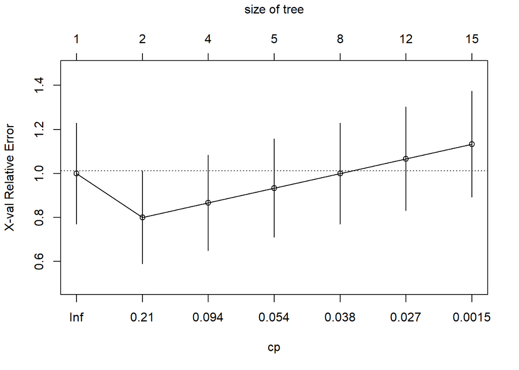

```r
plotcp(tree_model)
```

Visual representation of the tree:

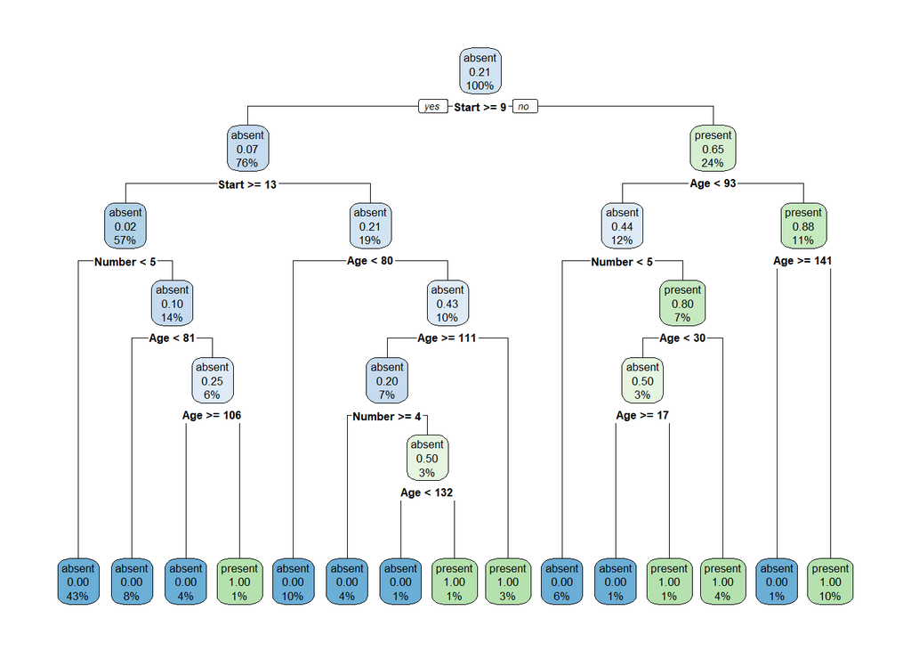

```r
library(rpart.plot)
rpart.plot(tree_model, extra = "auto")
```

**Computing Accuracy of the fitted tree**

```r
pred <- predict(tree_model, newdata = kyphosis.test, type = "class")
(conf_matrix_base <- table(kyphosis.test$Kyphosis, pred)) #confusion matrix
```

```
         pred
          absent present
  absent       5       2
  present      2       0
```

The confusion matrix shows that 5 cases are correctly classified as absence of kyphosis, while 0 were correctly classified as presence of kyphosis. The rest were misclassified.

```r
library(caret)
sensitivity(conf_matrix_base)
```

```
[1] 0.7142857
```

```r
specificity(conf_matrix_base)
```

```
[1] 0
```

```r
(mis.rate <- conf_matrix_base[1, 2] +
   conf_matrix_base[2, 1])/sum(conf_matrix_base)
```

```
[1] 0.4444444
```

The sensitivity is 0.71 and the specificity is 0. while the overall misclassification rate is about 44%.

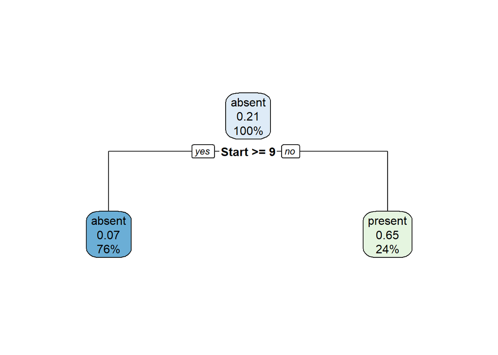

```r
prune_tree_model <- prune(tree_model, cp =
    tree_model$cptable[which.min(tree_model$cptable[, "xerror"]), "CP"])
rpart.plot(prune_tree_model, extra = "auto")
```

```r
summary(prune_tree_model)
```

```
Call:
rpart(formula = Kyphosis ~ ., data = kyphosis.train, control = rpart.control(minsplit = 1,
    cp = 1e-04))
  n= 72

         CP nsplit rel error xerror      xstd
1 0.3333333      0 1.0000000    1.0 0.2297341
2 0.1333333      1 0.6666667    0.8 0.2108185

Variable importance
 Start Number
    85     15

Node number 1: 72 observations,    complexity param=0.3333333
  predicted class=absent   expected loss=0.2083333  P(node) =1
    class counts:    57    15
   probabilities: 0.792 0.208
  left son=2 (55 obs) right son=3 (17 obs)
  Primary splits:
      Start  < 8.5  to the right, improve=8.567112, (0 missing)
      Number < 4.5  to the left,  improve=2.813830, (0 missing)
      Age    < 39.5 to the left,  improve=1.836957, (0 missing)
  Surrogate splits:
      Number < 6.5  to the left,  agree=0.806, adj=0.176, (0 split)

Node number 2: 55 observations
  predicted class=absent   expected loss=0.07272727  P(node) =0.7638889
    class counts:    51     4
   probabilities: 0.927 0.073

Node number 3: 17 observations
  predicted class=present  expected loss=0.3529412  P(node) =0.2361111
    class counts:     6    11
   probabilities: 0.353 0.647
```

Root node error is the proportion of the training set that was incorrectly classified by the root node of the tree, which is 0.208

The primary split is on **`Start`** < 8.5, indicating that the value of the **`Start`** variable is a strong predictor of Kyphosis presence.

The tree suggests that Start is the most critical factor in predicting Kyphosis after surgery, with the age and number of vertebrae involved also playing significant roles. However, the model’s cross-validation error suggests that a simpler model may generalize better.

```r
pred <- predict(prune_tree_model, newdata = kyphosis.test, type = "class")
(conf_matrix_base <- table(kyphosis.test$Kyphosis, pred)) #confusion matrix
```

```
         pred
          absent present
  absent       5       2
  present      2       0
```

After Pruning, The sensitivity is 0.71 and the specificity is 0. while the overall misclassification rate is about 44%.

**H)**

```r
library(ranger)

fit.rf.ranger <- ranger(Kyphosis ~ ., data = kyphosis.train,
                   importance = 'impurity', mtry = 3)
print(fit.rf.ranger)
```

```
Ranger result

Call:
 ranger(Kyphosis ~ ., data = kyphosis.train, importance = "impurity",      mtry = 3)

Type:                             Classification
Number of trees:                  500
Sample size:                      72
Number of independent variables:  3
Mtry:                             3
Target node size:                 1
Variable importance mode:         impurity
Splitrule:                        gini
OOB prediction error:             15.28 %
```

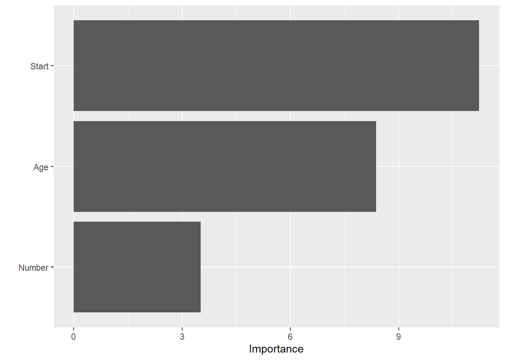

```r
library(vip)
v1 <- vi(fit.rf.ranger)
vip(v1)
```

After training a RF, we would like to understand which variables have the most predictive power. Variables with high importance will have a significant impact on the binary outcomes.

In our case **Start** is the most important variable **followed by age** and **then Number**.

```r
pred <- predict(fit.rf.ranger, data = kyphosis.test)
test_df <- data.frame(actual = kyphosis.test$Kyphosis, pred = NA)
test_df$pred <- pred$predictions
(conf_matrix_rf <- table(test_df$actual, test_df$pred))
```

```
          absent present
  absent       6       1
  present      2       0
```

```r
# Sensitivity
sensitivity(conf_matrix_rf)
```

```
[1] 0.75
```

The random forest model give us a sensitivity of 75%, which is better than the logit and decision tree model.

```r
# Specificity
specificity(conf_matrix_rf)
```

```
[1] 0
```

The specificity still remains 0.

```r
# Missclassification error rate:
(conf_matrix_rf[1,2] + conf_matrix_rf[2,1])/sum(conf_matrix_rf)
```

```
[1] 0.3333333
```

The Missclassification error rate reduced from 44% from decision tree to 33% in Random forest Model.

```r
library(randomForestSRC)
# Measure time for the ranger package

system.time({
  rf_ranger <- ranger(Kyphosis ~ ., data = kyphosis.train, probability = TRUE)
})
```

```
   user  system elapsed
   0.03    0.00    0.01
```

```r
# Measure time for the randomForestSRC package
system.time({
  rf_randomForestSRC <- rfsrc(Kyphosis ~ ., data = kyphosis.train)
})
```

```
   user  system elapsed
   0.05    0.00    0.06
```

It appears that both **`ranger`** and **`randomForestSRC`** have very fast execution times for the small dataset. There might be some difference inthe execution time when the data set size increases o number of trees in the forest and configuration of the hardware device used.

```r
predict(rf_randomForestSRC,newdata = kyphosis.test)
```

```
  Sample size of test (predict) data: 9
                Number of grow trees: 500
  Average no. of grow terminal nodes: 10.836
         Total no. of grow variables: 3
       Resampling used to grow trees: swor
    Resample size used to grow trees: 46
                            Analysis: RF-C
                              Family: class
                    Imbalanced ratio: 3.5
                         Brier score: 0.25382483
              Normalized Brier score: 1.01529931
                                 AUC: 0.42857143
                              PR-AUC: 0.19394071
                              G-mean: 0
         Requested performance error: 0.33333333, 0.14285714, 1

Confusion matrix:

          predicted
  observed absent present class.error
   absent       6       1      0.1429
   present      2       0      1.0000

           Misclassification error: 0.3333333
```

**I)**

```r
library(xgboost)
library(Matrix)

kyphosis.train$Kyphosis <- ifelse(kyphosis.train$Kyphosis=='present',1,0)
kyphosis.test$Kyphosis <- ifelse(kyphosis.test$Kyphosis=='present',1,0)


# Transform the predictor matrix using dummy (or indictor or one-hot) encoding
matrix_predictors.train <-
  as.matrix(sparse.model.matrix(Kyphosis ~., data = kyphosis.train))[, -1]
matrix_predictors.test <-
  as.matrix(sparse.model.matrix(Kyphosis ~., data = kyphosis.test))[, -1]
```

```r
# Train dataset
pred.train.gbm <- data.matrix(matrix_predictors.train) # predictors only

#convert factor to numeric
kyphosis.train.gbm <- as.numeric(as.character(kyphosis.train$Kyphosis))

dtrain <- xgb.DMatrix(data = pred.train.gbm, label = kyphosis.train.gbm)

# Test dataset
pred.test.gbm <- data.matrix(matrix_predictors.test) # predictors only

 #convert factor to numeric
kyphosis.test.gbm <- as.numeric(as.character(kyphosis.test$Kyphosis))
dtest <- xgb.DMatrix(data = pred.test.gbm, label = kyphosis.test.gbm)
```

The above code is used for the data preparation for the inputs into the XGB model.

```r
watchlist <- list(train = dtrain, test = dtest)
param <- list(max_depth = 2, eta = 1, nthread = 2,
              objective = "binary:logistic", eval_metric = "auc")
```

The watchlist is used to observe the model’s performance as it trains, and the parameters are tuned to guide the training process.

```r
model.xgb <- xgb.train(param, dtrain, nrounds = 2, watchlist)
```

[output not shown]

```r
pred.y.train <- predict(model.xgb, pred.train.gbm)
prediction.train <- as.numeric(pred.y.train > 0.5)
# Measure prediction accuracy on train data
(tab<-table(kyphosis.train.gbm, prediction.train))
```

```
                  prediction.train
kyphosis.train.gbm  0  1
                 0 56  1
                 1  8  7
```

```r
sum(diag(tab))/sum(tab)
```

```
[1] 0.875
```

The accuracy is 87.5% on the training data. The model predicts whether a child has kyphosis after the operation 87 times correclty out of 100.

Evaluating the XGB models performance on the test dataset:

```r
pred.y = predict(model.xgb, pred.test.gbm)
prediction <- as.numeric(pred.y > 0.5)
```

```r
# Measure prediction accuracy on test data
(tab1<-table(kyphosis.test.gbm,prediction))
```

```
                 prediction
kyphosis.test.gbm 0 1
                0 6 1
                1 2 0
```

The proportion of total cases that were correctly identified is 66.6%.

The model appears to have a significant issue with identifying positive cases of kyphosis, as evidenced by a recall of 0%.

It’s more effective at identifying negative cases, as shown by the higher specificity which is 85.7%.